# IODS course project

Kim Ståhlberg

# About the project

*Write a short description about the course and add a link to your github repository here. This is an R markdown (.Rmd) file so you can use R markdown syntax. See the ‘Useful links’ page in the mooc area (chapter 1) for instructions.*

This course is interesting. It is nice to learn RStudio and GitHub stuff. Great.

Here is link to my GitHub repository:

https://github.com/kimsta/IODS-project

# Chapter 2

*Describe the work you have done this week and summarize your learning.*

This week I have read some data from the internet and created a subset from that data with Rstudio and uploaded it into my GitHub repository. I have learned to analyse my dataset with some simple regression analysis and linear modeling. I have also learned to view my data graphicly with libraries GGally and ggplot2.

Report:

I can read my file as follows:

```r
learning <- read.csv("data/learning.csv", sep = ",", header = T)
dim(learning)
```

```
## [1] 166   7
```

```r
str(learning)
```

```
## 'data.frame':    166 obs. of  7 variables:
##  $ gender  : Factor w/ 2 levels "F","M": 1 2 1 2 2 1 2 1 2 1 ...
##  $ age     : int  53 55 49 53 49 38 50 37 37 42 ...
##  $ attitude: num  3.7 3.1 2.5 3.5 3.7 3.8 3.5 2.9 3.8 2.1 ...
##  $ deep    : num  3.58 2.92 3.5 3.5 3.67 ...
##  $ stra    : num  3.38 2.75 3.62 3.12 3.62 ...
##  $ surf    : num  2.58 3.17 2.25 2.25 2.83 ...
##  $ points  : int  25 12 24 10 22 21 21 31 24 26 ...
```

I named my dataset as learning. It has 7 variables and 166 observations.

Variable attitude represents students attitude. Variable deep represents students deep learning skills. Variable stra represents students strategic learning skills. Variable surf represents students surface learning skills.

All variables above are scaled back to scale 1-5 by taking a mean from a question set in question.

Variables gender and age are self explanatory. Variable points is a sum of points from an exam. Observations where points < 1 are left out from this subset.

Variables can be seen in a scatterplot (excluding gender) as follows:

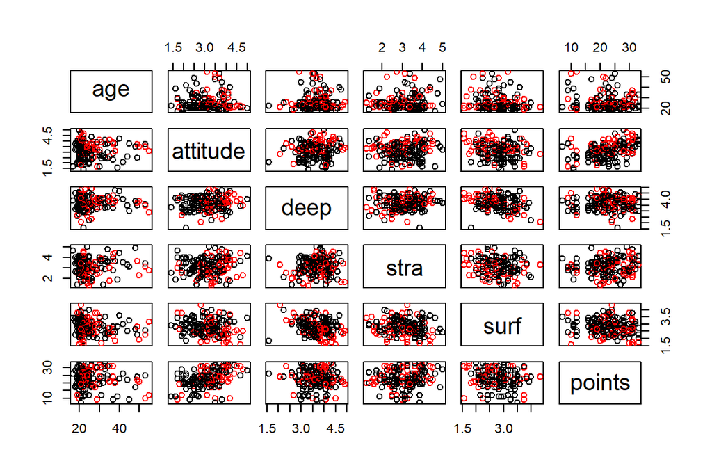

```r
pairs(learning[-1], col = learning$gender)
```

If we use libraries GGally and ggplot2 we can see some more detailed information about variables.

```r
library(GGally)
```

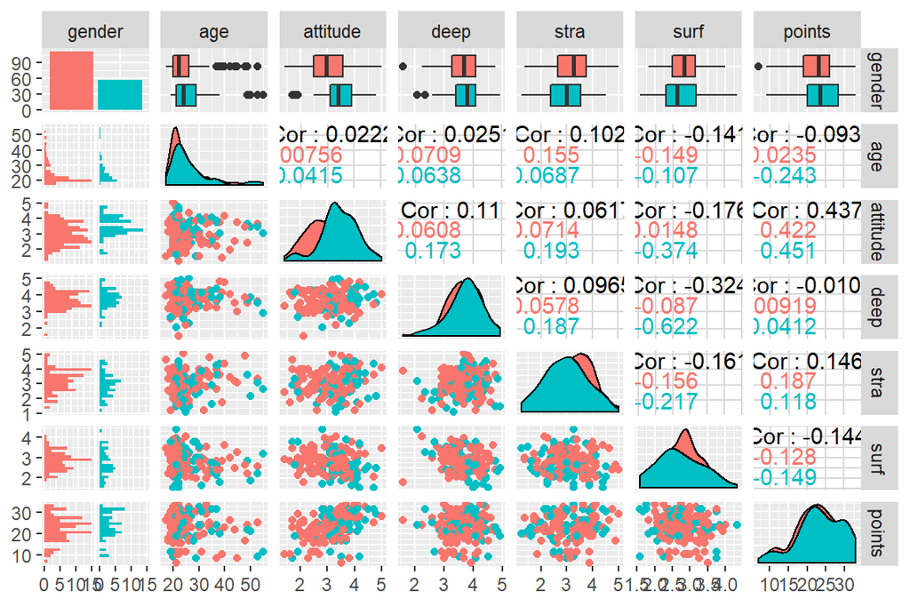

```r
library(ggplot2)

p <- ggpairs(learning, mapping = aes(col = learning$gender), lower = list(combo = wrap("facethist", bins = 20)))
p
```

Now we choose three variables that explains variable points most likely. We choose variables that has highes absolute value of correlation with points; attitude, stra and surf.

```r
my_model <- lm(points ~ attitude + stra + surf, data = learning)
my_model
```

```
##
## Call:
## lm(formula = points ~ attitude + stra + surf, data = learning)
##
## Coefficients:
## (Intercept)     attitude         stra         surf
##     11.0171       3.3952       0.8531      -0.5861
```

It seems like attitude explains most points and surf correlates slightly negatively with points.